# Homework 3

Toygar Emre

31 12 2020

```r
library(tidyverse,quietly = T)
library(lubridate,quietly = T)
library(doSNOW,quietly = T)
```

```r
# Our performance metric
mape_fnc<-function(actual,prediction){
  if(length(actual)==length(prediction)){
    tmp<-sum(abs((actual-prediction)/actual))/length(actual)*100
    return(tmp)
  }else{
    return(0)
    print("lengths are not equal")
  }
}
```

Uploading Data

```r
rawdat<-read.csv("GercekZamanliTuketim-01012016-01122020.csv") %>% as_tibble()
colnames(rawdat)<-c("Date","Hour","Consumption")

rawdat<-rawdat %>%
  mutate(Consumption=gsub(".", "", Consumption, fixed = TRUE),
         Consumption=gsub(",", ".", Consumption, fixed = TRUE),
         Consumption=as.numeric(Consumption),
         Date=as.Date(Date,format="%d.%m.%Y")) %>%
  separate(Hour,c("Hour","Minute")) %>%
  mutate(Hour=as.numeric(Hour)) %>%
  arrange(Date)
rawdat %>% head
```

```
## # A tibble: 6 x 4
##   Date        Hour Minute Consumption
##   <date>     <dbl> <chr>        <dbl>
## 1 2016-01-01     0 00          26277.
## 2 2016-01-01     1 00          24992.
## 3 2016-01-01     2 00          23533.
## 4 2016-01-01     3 00          22465.
## 5 2016-01-01     4 00          22003.
## 6 2016-01-01     5 00          21957.
```

Checking if data has some problems

```r
unique(rawdat$Minute)
```

```
## [1] "00"
```

```r
#So we can remove Minute column since it is unimportant
rawdat<-select(rawdat,-Minute)
```

```r
unique(rawdat$Hour)
```

```
##  [1]  0  1  2  3  4  5  6  7  8  9 10 11 12 13 14 15 16 17 18 19 20 21 22 23
```

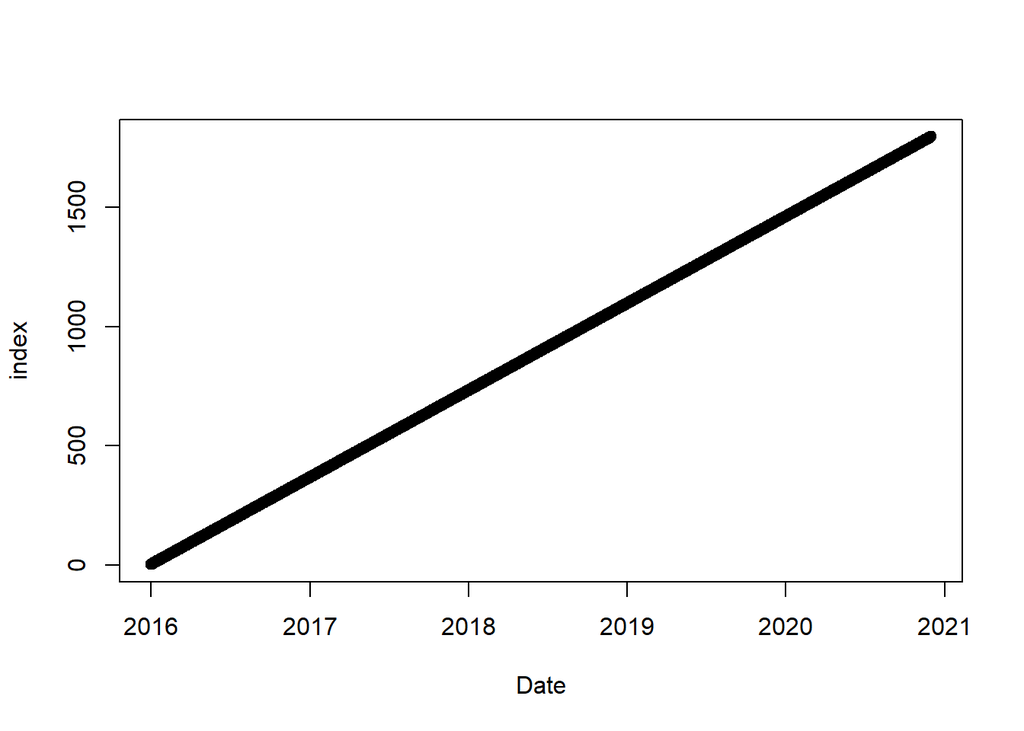

```r
plot(x=unique(rawdat$Date),y=1:length(unique(rawdat$Date)),ylab="index",xlab="Date")
```

```r
#Everything seems fine
```

```r
identical(unique(rawdat$Date),seq.Date(from = as.Date("2016-01-01"),to = as.Date("2020-12-01"),by="day"))
```

```
## [1] TRUE
```

```r
#So we have every day from start to end. no missing and excess values
```

PART A

```r
#We delete the day if has noisy data
#For some dates, we check if there is more than 1 unique hour
dat<-rawdat %>% group_by(Date,Hour) %>%
  mutate(n_Hour=n()) %>%
  group_by(Date) %>%
  mutate(n_Hour=max(n_Hour)) %>%
  ungroup()
unique(dat$n_Hour)
```

```
## [1] 1 2
```

```r
#Yes there are and we would like to remove those days from the data
#However we need 2 and 7 days lag. Therefore, before removing we need to take lag
```

```r
dat.longer<-dat %>%
  arrange(Date,Hour) %>%
  group_by(Hour) %>%
  mutate(Lag_48=dplyr::lag(Consumption,n=2),
         Lag_168=dplyr::lag(Consumption,n=7)) %>%
  ungroup()

noisy.dates<-dat.longer %>% filter(n_Hour!=1) %>% pull(Date) %>% unique()
noisy.dates
```

```
## [1] "2016-03-27"
```

```r
# Only 1 date is noisy but it affects the following 2 and 7 days
# So I also removed the following 2 and 7 days.
dat.longer<-dat.longer %>% filter(!(Date %in% c(noisy.dates,noisy.dates+2,noisy.dates+7))) %>%
  select(Date,Hour,Lag_48,Lag_168,Consumption) %>%
  filter(Date>"2016-01-07")
#Before 2016-01-07 there are NA values. We would like remove those ones.
dat.longer %>% head
```

```
## # A tibble: 6 x 5
##   Date        Hour Lag_48 Lag_168 Consumption
##   <date>     <dbl>  <dbl>   <dbl>       <dbl>
## 1 2016-01-08     0 29189.  26277.      28602.
## 2 2016-01-08     1 27614.  24992.      27112.
## 3 2016-01-08     2 26579.  23533.      25975.
## 4 2016-01-08     3 25719.  22465.      25316.
## 5 2016-01-08     4 25865.  22003.      25128.
## 6 2016-01-08     5 25919.  21957.      25356.
```

```r
train.dat<-dat.longer %>% filter(Date<"2020-11-01")
test.dat<-dat.longer %>% filter(Date>="2020-11-01")

Predictions.all<-test.dat

mape_res48_parta<-mape_fnc(actual = test.dat$Consumption,prediction = test.dat$Lag_48)
mape_res168_parta<-mape_fnc(actual = test.dat$Consumption,prediction = test.dat$Lag_168)
paste0("MAPE for 48 hour lag is ",round(mape_res48_parta,2)," %")
```

```
## [1] "MAPE for 48 hour lag is 8.06 %"
```

```r
paste0("MAPE for 168 hour lag is ",round(mape_res168_parta,2)," %")
```

```
## [1] "MAPE for 168 hour lag is 3.45 %"
```

7 days lag seems to give better forecast than 2 days lag. We can say that there is a day of week effect and time of day effect in electricity consumption. In the homework it is explained that seasonality takes a crucial place and our mape values proves that situation. While 2 days only includes time of day effect, 7 days includes both time of day and day of week. So both seasonality is important.

PART B

```r
train.fit<-lm(formula = Consumption~Lag_48+Lag_168,data = train.dat)
summary(train.fit)
```

```
##
## Call:
## lm(formula = Consumption ~ Lag_48 + Lag_168, data = train.dat)
##
## Residuals:
##      Min       1Q   Median       3Q      Max
## -17125.7   -984.4     -1.2   1015.7  16097.4
##
## Coefficients:
##              Estimate Std. Error t value Pr(>|t|)
## (Intercept) 1.570e+03  8.351e+01   18.80   <2e-16 ***
## Lag_48      3.091e-01  3.096e-03   99.83   <2e-16 ***
## Lag_168     6.430e-01  3.094e-03  207.83   <2e-16 ***
## ---
## Signif. codes:  0 '***' 0.001 '**' 0.01 '*' 0.05 '.' 0.1 ' ' 1
##
## Residual standard error: 2388 on 42141 degrees of freedom
## Multiple R-squared:  0.7757, Adjusted R-squared:  0.7757
## F-statistic: 7.287e+04 on 2 and 42141 DF,  p-value: < 2.2e-16
```

```r
#Both features are significant
predictions<-predict.lm(object = train.fit,newdata = test.dat)

Predictions.all$lm<-predictions

mape_res_partb<-mape_fnc(actual = test.dat$Consumption,prediction = predictions)
paste0("MAPE  is ",round(mape_res_partb,2)," %")
```

```
## [1] "MAPE  is 4.23 %"
```

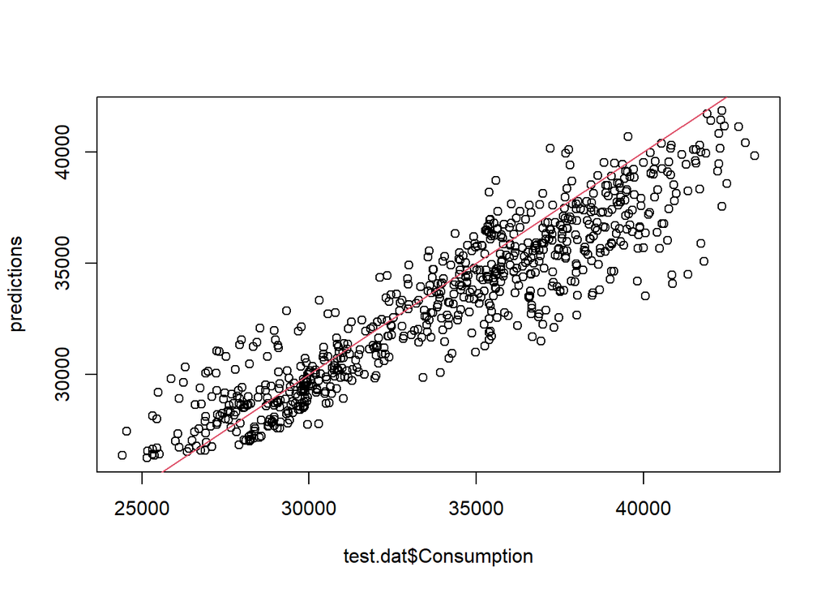

```r
plot(test.dat$Consumption,predictions)
abline(a=0,b=1,col=2)
```

4.23% is not better than 7 days lag prediction but better than 2 days lag prediction. So we can conclude that linear regression cannot beat our naive forecast. We need a sophisticated model.

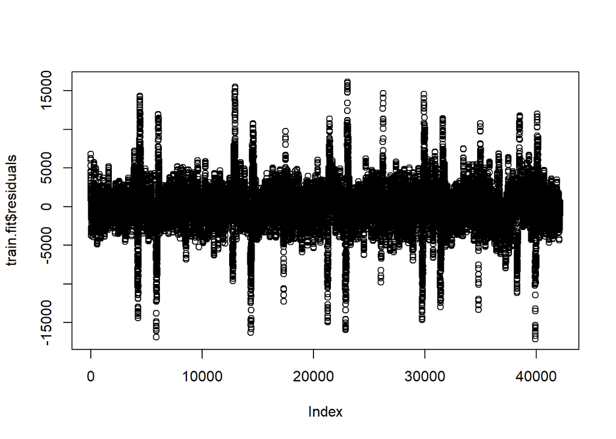

```r
plot(train.fit$residuals)
```

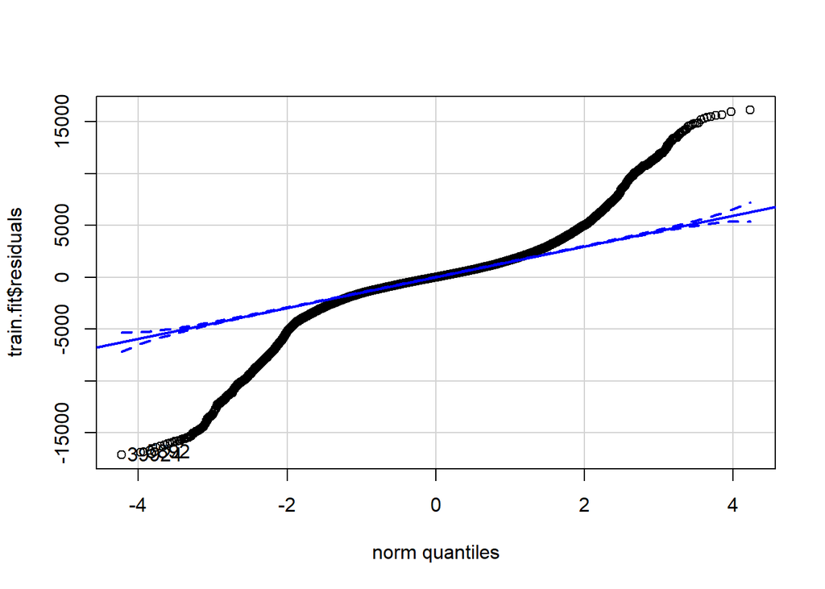

```
## [1] 39924  5892
```

```r
car::qqPlot(train.fit$residuals,distribution="norm")
```

Residuals show some pattern so we cannot satisfy independency entirely. As can be seen from qqplot it didn’t satisfy normality assumption of linear regression.

PART C

```r
#Training models for each hour
full.test.dat<-c()
for(tmp.hour in 0:23){

  train.tmp<-train.dat %>% filter(Hour==tmp.hour)
  test.tmp<-test.dat %>% filter(Hour==tmp.hour)

  fit.tmp<-lm(formula = Consumption~Lag_48+Lag_168,data = train.tmp)
  paste0("fit for Hour: ",tmp.hour)
  summary(fit.tmp)
  predictions.tmp<-predict.lm(object = fit.tmp,newdata = test.tmp)
  test.tmp$Predictions<-predictions.tmp
  full.test.dat<-rbind(full.test.dat,test.tmp)

  mape_res<-mape_fnc(actual = test.tmp$Consumption,prediction = test.tmp$Predictions)
  print(paste0("MAPE for Hour ",tmp.hour," is ",round(mape_res,2)," %"))
}
```

```
## [1] "MAPE for Hour 0 is 3.26 %"
## [1] "MAPE for Hour 1 is 3.28 %"
## [1] "MAPE for Hour 2 is 3.42 %"
## [1] "MAPE for Hour 3 is 3.2 %"
## [1] "MAPE for Hour 4 is 3.18 %"
## [1] "MAPE for Hour 5 is 3.19 %"
## [1] "MAPE for Hour 6 is 3.15 %"
## [1] "MAPE for Hour 7 is 3.78 %"
## [1] "MAPE for Hour 8 is 4.68 %"
## [1] "MAPE for Hour 9 is 5.49 %"
## [1] "MAPE for Hour 10 is 6.09 %"
## [1] "MAPE for Hour 11 is 6.28 %"
## [1] "MAPE for Hour 12 is 6.55 %"
## [1] "MAPE for Hour 13 is 6.69 %"
## [1] "MAPE for Hour 14 is 6.49 %"
## [1] "MAPE for Hour 15 is 6.09 %"
## [1] "MAPE for Hour 16 is 5.15 %"
## [1] "MAPE for Hour 17 is 4.61 %"
## [1] "MAPE for Hour 18 is 3.74 %"
## [1] "MAPE for Hour 19 is 3.44 %"
## [1] "MAPE for Hour 20 is 3.17 %"
## [1] "MAPE for Hour 21 is 3.17 %"
## [1] "MAPE for Hour 22 is 3.17 %"
## [1] "MAPE for Hour 23 is 3.39 %"
```

```r
Predictions.all<-Predictions.all %>% left_join(full.test.dat %>%
                                                 select(Date,Hour,Predictions) %>%
                                                 rename(lm_24=Predictions),by=c("Date","Hour"))
mape_res_partc<-mape_fnc(actual = full.test.dat$Consumption,prediction = full.test.dat$Predictions)
print(paste0("Total MAPE is ",round(mape_res_partc,2)," %"))
```

```
## [1] "Total MAPE is 4.36 %"
```

Overall, more sophisticated regression model does not help to improve our forecast (4.36 > 4.23(part b)) We have better forecast in the evenings compared to daytime. We will discuss this in part f.

PART D

```r
library(glmnet,quietly = T)
find_value<-function(x){
  as.numeric(na.omit(unique(x)))
}
#Make data wider
dat.wider<-dat.longer %>% rename(Lag_day2=Lag_48,Lag_day7=Lag_168) %>%
  mutate(Hour_ind=Hour) %>%
  pivot_wider(names_from = Hour_ind,values_from=c(Lag_day2,Lag_day7),names_sep="_hour_",
              values_fn=list(Lag_day2_hour_0=find_value)) %>%
  group_by(Date) %>%
  mutate_at(.vars = 4:ncol(.),.funs = find_value) %>%
  ungroup()

dat.wider %>% head
```

```
## # A tibble: 6 x 51
##   Date        Hour Consumption Lag_day2_hour_0 Lag_day2_hour_1 Lag_day2_hour_2
##   <date>     <dbl>       <dbl>           <dbl>           <dbl>           <dbl>
## 1 2016-01-08     0      28602.          29189.          27614.          26579.
## 2 2016-01-08     1      27112.          29189.          27614.          26579.
## 3 2016-01-08     2      25975.          29189.          27614.          26579.
## 4 2016-01-08     3      25316.          29189.          27614.          26579.
## 5 2016-01-08     4      25128.          29189.          27614.          26579.
## 6 2016-01-08     5      25356.          29189.          27614.          26579.
## # ... with 45 more variables: Lag_day2_hour_3 <dbl>, Lag_day2_hour_4 <dbl>,
## #   Lag_day2_hour_5 <dbl>, Lag_day2_hour_6 <dbl>, Lag_day2_hour_7 <dbl>,
## #   Lag_day2_hour_8 <dbl>, Lag_day2_hour_9 <dbl>, Lag_day2_hour_10 <dbl>,
## #   Lag_day2_hour_11 <dbl>, Lag_day2_hour_12 <dbl>, Lag_day2_hour_13 <dbl>,
## #   Lag_day2_hour_14 <dbl>, Lag_day2_hour_15 <dbl>, Lag_day2_hour_16 <dbl>,
## #   Lag_day2_hour_17 <dbl>, Lag_day2_hour_18 <dbl>, Lag_day2_hour_19 <dbl>,
## #   Lag_day2_hour_20 <dbl>, Lag_day2_hour_21 <dbl>, Lag_day2_hour_22 <dbl>,
## #   Lag_day2_hour_23 <dbl>, Lag_day7_hour_0 <dbl>, Lag_day7_hour_1 <dbl>,
## #   Lag_day7_hour_2 <dbl>, Lag_day7_hour_3 <dbl>, Lag_day7_hour_4 <dbl>,
## #   Lag_day7_hour_5 <dbl>, Lag_day7_hour_6 <dbl>, Lag_day7_hour_7 <dbl>,
## #   Lag_day7_hour_8 <dbl>, Lag_day7_hour_9 <dbl>, Lag_day7_hour_10 <dbl>,
## #   Lag_day7_hour_11 <dbl>, Lag_day7_hour_12 <dbl>, Lag_day7_hour_13 <dbl>,
## #   Lag_day7_hour_14 <dbl>, Lag_day7_hour_15 <dbl>, Lag_day7_hour_16 <dbl>,
## #   Lag_day7_hour_17 <dbl>, Lag_day7_hour_18 <dbl>, Lag_day7_hour_19 <dbl>,
## #   Lag_day7_hour_20 <dbl>, Lag_day7_hour_21 <dbl>, Lag_day7_hour_22 <dbl>,
## #   Lag_day7_hour_23 <dbl>
```

```r
train.data<-dat.wider %>% filter(Date<"2020-11-01")
test.data<-dat.wider %>% filter(Date>="2020-11-01")

#Below, for each hour and parameter we create folds and record the mape values
#Since algorithm is slow, we decided to use parallel computing
full.test.dat<-c()
chosen.lambdas.min<-c()
chosen.lambdas.1se<-c()
fit.list<-list()
for(tmp.hour in 0:23){

  train.tmp<-train.data %>% filter(Hour==tmp.hour)
  test.tmp<-test.data %>% filter(Hour==tmp.hour)

  cl=makeCluster(8)
  registerDoSNOW(cl)
  set.seed(123)
  cv.fit<-cv.glmnet(x = as.matrix(train.tmp[,4:ncol(train.tmp)]),
                    y = train.tmp$Consumption,nfolds = 10,
                    nlambda=100,
                    type.measure="mae",
                    parallel = T,keep=T)
  stopCluster(cl)
  fit.list[[tmp.hour+1]]<-cv.fit
  chosen.lambdas.min<-c(chosen.lambdas.min,cv.fit$lambda.min)
  chosen.lambdas.1se<-c(chosen.lambdas.1se,cv.fit$lambda.1se)

  predictions.min<-predict(object = cv.fit, newx = as.matrix(test.tmp[,4:ncol(test.tmp)]),
                           s="lambda.min",type="response")

  predictions.1se<-predict(object = cv.fit, newx = as.matrix(test.tmp[,4:ncol(test.tmp)]),
                           s="lambda.1se",type="response")
  test.tmp$Predictions.min<-as.numeric(predictions.min)
  test.tmp$Predictions.1se<-as.numeric(predictions.1se)

  full.test.dat<-rbind(full.test.dat,test.tmp)

  mape_res_min<-mape_fnc(actual = test.tmp$Consumption,prediction = test.tmp$Predictions.min)
  print(paste0("MAPE with min lambda for Hour ",tmp.hour," is ",round(mape_res_min,2)," %"))
  mape_res_1se<-mape_fnc(actual = test.tmp$Consumption,prediction = test.tmp$Predictions.1se)
  print(paste0("MAPE with 1se lambda for Hour ",tmp.hour," is ",round(mape_res_1se,2)," %"))
}
```

```
## [1] "MAPE with min lambda for Hour 0 is 1.4 %"
## [1] "MAPE with 1se lambda for Hour 0 is 1.47 %"
## [1] "MAPE with min lambda for Hour 1 is 1.48 %"
## [1] "MAPE with 1se lambda for Hour 1 is 1.53 %"
## [1] "MAPE with min lambda for Hour 2 is 1.47 %"
## [1] "MAPE with 1se lambda for Hour 2 is 1.52 %"
## [1] "MAPE with min lambda for Hour 3 is 1.38 %"
## [1] "MAPE with 1se lambda for Hour 3 is 1.39 %"
## [1] "MAPE with min lambda for Hour 4 is 1.36 %"
## [1] "MAPE with 1se lambda for Hour 4 is 1.42 %"
## [1] "MAPE with min lambda for Hour 5 is 1.38 %"
## [1] "MAPE with 1se lambda for Hour 5 is 1.44 %"
## [1] "MAPE with min lambda for Hour 6 is 1.63 %"
## [1] "MAPE with 1se lambda for Hour 6 is 1.64 %"
## [1] "MAPE with min lambda for Hour 7 is 1.8 %"
```

[output cut: 33 more lines]

```r
Predictions.all<-Predictions.all %>% left_join(full.test.dat %>%
                                                 select(Date,Hour,Predictions.min,Predictions.1se) %>%
                                                 rename(glmnet.min=Predictions.min,glmnet.1se=Predictions.1se),by=c("Date","Hour"))
# Results for each hour shows that mape is higher during daytime
mape_res_partd_min<-mape_fnc(actual = full.test.dat$Consumption,prediction = full.test.dat$Predictions.min)
print(paste0("Total MAPE for min lambda is ",round(mape_res_partd_min,2)," %"))
```

```
## [1] "Total MAPE for min lambda is 2.45 %"
```

```r
mape_res_partd_1se<-mape_fnc(actual = full.test.dat$Consumption,prediction = full.test.dat$Predictions.1se)
print(paste0("Total MAPE for 1se lambda is ",round(mape_res_partd_1se,2)," %"))
```

```
## [1] "Total MAPE for 1se lambda is 2.49 %"
```

With lasso regression MAPE has decreased meaning that our forecast has improved. We beat our naive forecast. Moreover, min lambda gives better MAPE result than 1 se lambda overall. Only for Hours between 18 to 23, 1se lambda gives better result.

The ones with zero coefficients are the ones which increase the potential error of the model. So those parameters should be keep at zero level in order to ensure fitness of the model.

```r
#Example fit for 15th Hour
tmp.hour<-15
fit.list[[tmp.hour+1]]$lambda.min
```

```
## [1] 2.21022
```

```r
coef(fit.list[[tmp.hour+1]],s="lambda.min")
```

```
## 49 x 1 sparse Matrix of class "dgCMatrix"
##                              1
## (Intercept)       6.348016e+03
## Lag_day2_hour_0  -1.195866e+00
## Lag_day2_hour_1  -1.430464e-01
## Lag_day2_hour_2  -6.891123e-01
## Lag_day2_hour_3  -2.329499e-01
## Lag_day2_hour_4   7.386996e-01
## Lag_day2_hour_5   1.440008e+00
## Lag_day2_hour_6   .
## Lag_day2_hour_7   6.655139e-01
## Lag_day2_hour_8  -3.691369e-01
## Lag_day2_hour_9  -1.184640e+00
## Lag_day2_hour_10  .
## Lag_day2_hour_11 -1.594645e-01
## Lag_day2_hour_12  2.457814e-02
## Lag_day2_hour_13  1.704522e+00
## Lag_day2_hour_14 -8.149086e-01
## Lag_day2_hour_15  9.095304e-05
## Lag_day2_hour_16  .
## Lag_day2_hour_17  .
## Lag_day2_hour_18  3.162422e-01
## Lag_day2_hour_19  .
## Lag_day2_hour_20 -4.334465e-02
## Lag_day2_hour_21  .
## Lag_day2_hour_22 -2.915992e-02
## Lag_day2_hour_23  1.315664e+00
## Lag_day7_hour_0   .
## Lag_day7_hour_1   4.669114e-01
## Lag_day7_hour_2   .
## Lag_day7_hour_3   6.636326e-02
## Lag_day7_hour_4  -1.531828e-01
## Lag_day7_hour_5  -1.366015e+00
## Lag_day7_hour_6  -2.950108e-01
## Lag_day7_hour_7   6.328948e-01
## Lag_day7_hour_8   6.187181e-01
## Lag_day7_hour_9   .
## Lag_day7_hour_10  .
## Lag_day7_hour_11 -2.305399e-01
## Lag_day7_hour_12 -2.608140e-01
## Lag_day7_hour_13  6.034434e-02
## Lag_day7_hour_14  .
## Lag_day7_hour_15  4.269201e-01
## Lag_day7_hour_16  4.767092e-01
## Lag_day7_hour_17  1.005862e-01
## Lag_day7_hour_18 -5.329824e-01
## Lag_day7_hour_19 -3.398790e-01
## Lag_day7_hour_20 -3.359250e-01
## Lag_day7_hour_21  1.462966e-01
## Lag_day7_hour_22  .
## Lag_day7_hour_23  1.891707e-01
```

```r
fit.list[[tmp.hour+1]]$lambda.1se
```

```
## [1] 15.59266
```

```r
coef(fit.list[[tmp.hour+1]],s="lambda.1se")
```

```
## 49 x 1 sparse Matrix of class "dgCMatrix"
##                              1
## (Intercept)      4552.34974374
## Lag_day2_hour_0    -0.53994587
## Lag_day2_hour_1     .
## Lag_day2_hour_2    -0.11744259
## Lag_day2_hour_3     .
## Lag_day2_hour_4     .
## Lag_day2_hour_5     0.55340432
## Lag_day2_hour_6     .
## Lag_day2_hour_7     0.13545756
## Lag_day2_hour_8     .
## Lag_day2_hour_9    -1.11566634
## Lag_day2_hour_10    .
## Lag_day2_hour_11    .
## Lag_day2_hour_12    .
## Lag_day2_hour_13    0.72604394
## Lag_day2_hour_14    .
## Lag_day2_hour_15    .
## Lag_day2_hour_16    .
## Lag_day2_hour_17    .
## Lag_day2_hour_18    0.07583164
## Lag_day2_hour_19    .
## Lag_day2_hour_20    0.21886576
## Lag_day2_hour_21    .
## Lag_day2_hour_22    .
## Lag_day2_hour_23    1.13689899
## Lag_day7_hour_0     .
## Lag_day7_hour_1     .
## Lag_day7_hour_2     .
## Lag_day7_hour_3     .
## Lag_day7_hour_4    -0.22199790
## Lag_day7_hour_5    -0.74299659
## Lag_day7_hour_6     .
## Lag_day7_hour_7     0.17955268
## Lag_day7_hour_8     0.61859384
## Lag_day7_hour_9     .
## Lag_day7_hour_10    .
## Lag_day7_hour_11    .
## Lag_day7_hour_12    .
## Lag_day7_hour_13    .
## Lag_day7_hour_14    .
## Lag_day7_hour_15    .
## Lag_day7_hour_16    0.45440624
## Lag_day7_hour_17    0.01041226
## Lag_day7_hour_18    .
## Lag_day7_hour_19   -0.39612956
## Lag_day7_hour_20   -0.11337585
## Lag_day7_hour_21    .
## Lag_day7_hour_22    .
## Lag_day7_hour_23    .
```

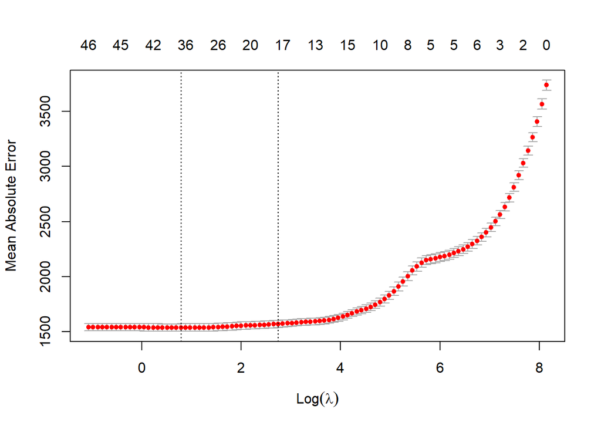

```r
plot(fit.list[[tmp.hour+1]])
```

As we can see from the figures, whereas lambda increases our residuals also increases. lambda.min has 12 zero coefficients and 37 nonzero coefficients lambda.1se has 31 zero coefficients and 17 nonzero coefficients

```r
#Example fit for 10th Hour
tmp.hour<-10
fit.list[[tmp.hour+1]]$lambda.min
```

```
## [1] 7.768836
```

```r
coef(fit.list[[tmp.hour+1]],s="lambda.min")
```

```
## 49 x 1 sparse Matrix of class "dgCMatrix"
##                              1
## (Intercept)       6.673585e+03
## Lag_day2_hour_0  -7.885599e-01
## Lag_day2_hour_1  -1.512259e-01
## Lag_day2_hour_2  -3.864928e-01
## Lag_day2_hour_3   .
## Lag_day2_hour_4   .
## Lag_day2_hour_5   1.121914e+00
## Lag_day2_hour_6   .
## Lag_day2_hour_7   5.540309e-01
## Lag_day2_hour_8  -1.810796e-03
## Lag_day2_hour_9  -1.324965e+00
## Lag_day2_hour_10  .
## Lag_day2_hour_11 -2.267134e-04
## Lag_day2_hour_12  .
## Lag_day2_hour_13  1.460956e+00
## Lag_day2_hour_14 -6.638732e-01
## Lag_day2_hour_15  .
## Lag_day2_hour_16  .
## Lag_day2_hour_17  .
## Lag_day2_hour_18  .
## Lag_day2_hour_19  .
## Lag_day2_hour_20  1.500224e-01
## Lag_day2_hour_21  .
## Lag_day2_hour_22  1.205809e-02
## Lag_day2_hour_23  1.264426e+00
## Lag_day7_hour_0   .
## Lag_day7_hour_1   .
## Lag_day7_hour_2   .
## Lag_day7_hour_3   .
## Lag_day7_hour_4   .
## Lag_day7_hour_5  -1.059370e+00
## Lag_day7_hour_6   .
## Lag_day7_hour_7   4.750854e-01
## Lag_day7_hour_8   5.588805e-01
## Lag_day7_hour_9   2.636198e-01
## Lag_day7_hour_10  6.639652e-03
## Lag_day7_hour_11  .
## Lag_day7_hour_12  .
## Lag_day7_hour_13  .
## Lag_day7_hour_14  .
## Lag_day7_hour_15  1.630148e-01
## Lag_day7_hour_16  7.711812e-02
## Lag_day7_hour_17  .
## Lag_day7_hour_18  .
## Lag_day7_hour_19 -4.014789e-01
## Lag_day7_hour_20 -3.729640e-01
## Lag_day7_hour_21  .
## Lag_day7_hour_22  .
## Lag_day7_hour_23  .
```

```r
fit.list[[tmp.hour+1]]$lambda.1se
```

```
## [1] 19.69683
```

```r
coef(fit.list[[tmp.hour+1]],s="lambda.1se")
```

```
## 49 x 1 sparse Matrix of class "dgCMatrix"
##                              1
## (Intercept)      5957.32250653
## Lag_day2_hour_0    -0.11647811
## Lag_day2_hour_1    -0.17710672
## Lag_day2_hour_2    -0.23273495
## Lag_day2_hour_3     .
## Lag_day2_hour_4     .
## Lag_day2_hour_5     0.26400880
## Lag_day2_hour_6     0.07437651
## Lag_day2_hour_7     0.26476354
## Lag_day2_hour_8     .
## Lag_day2_hour_9    -1.02181825
## Lag_day2_hour_10    .
## Lag_day2_hour_11    .
## Lag_day2_hour_12    .
## Lag_day2_hour_13    0.67377299
## Lag_day2_hour_14    .
## Lag_day2_hour_15    .
## Lag_day2_hour_16    .
## Lag_day2_hour_17    .
## Lag_day2_hour_18    .
## Lag_day2_hour_19    .
## Lag_day2_hour_20    0.28341680
## Lag_day2_hour_21    .
## Lag_day2_hour_22    .
## Lag_day2_hour_23    1.02228047
## Lag_day7_hour_0     .
## Lag_day7_hour_1     .
## Lag_day7_hour_2    -0.05240441
## Lag_day7_hour_3     .
## Lag_day7_hour_4    -0.54463987
## Lag_day7_hour_5    -0.35289069
## Lag_day7_hour_6     .
## Lag_day7_hour_7     0.19529480
## Lag_day7_hour_8     0.57923663
## Lag_day7_hour_9     0.42529831
## Lag_day7_hour_10    0.05756454
## Lag_day7_hour_11    .
## Lag_day7_hour_12    .
## Lag_day7_hour_13    .
## Lag_day7_hour_14    .
## Lag_day7_hour_15    0.02069458
## Lag_day7_hour_16    0.04365623
## Lag_day7_hour_17    .
## Lag_day7_hour_18    .
## Lag_day7_hour_19   -0.17316320
## Lag_day7_hour_20   -0.42934433
## Lag_day7_hour_21    .
## Lag_day7_hour_22    .
## Lag_day7_hour_23    .
```

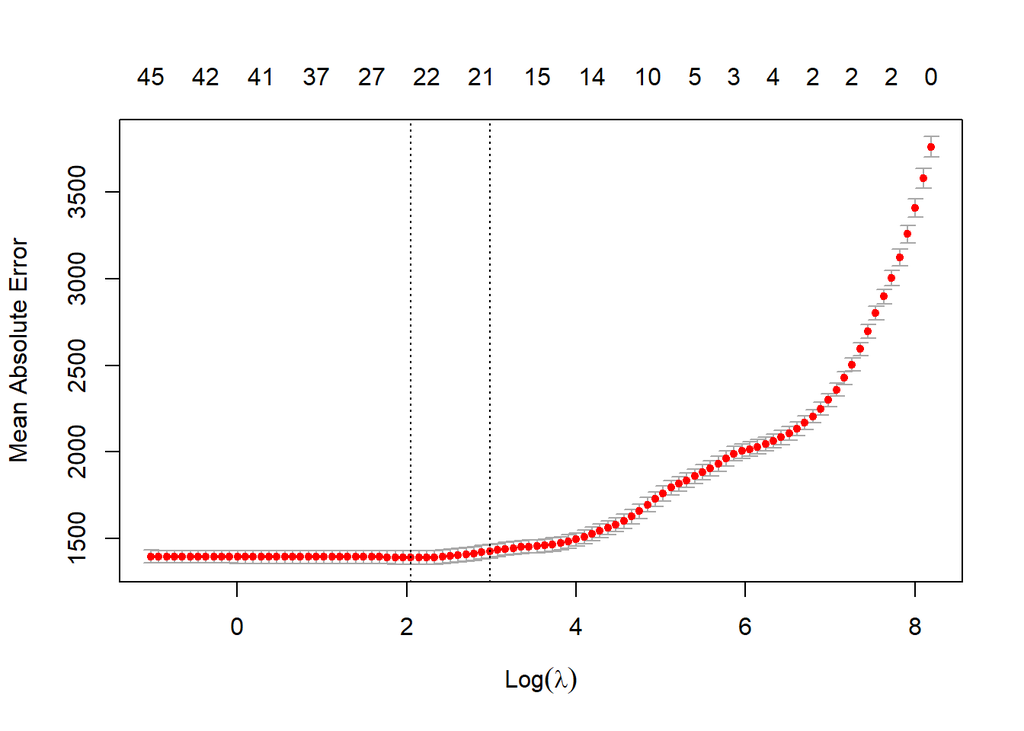

```r
plot(fit.list[[tmp.hour+1]])
```

lambda.min has 26 zero coefficients and 22 nonzero coefficients lambda.1se has 27 zero coefficients and 21 nonzero coefficients

```r
#Example fit for 10th Hour
tmp.hour<-5
fit.list[[tmp.hour+1]]$lambda.min
```

```
## [1] 4.495126
```

```r
coef(fit.list[[tmp.hour+1]],s="lambda.min")
```

```
## 49 x 1 sparse Matrix of class "dgCMatrix"
##                              1
## (Intercept)       1.016983e+03
## Lag_day2_hour_0  -4.906643e-01
## Lag_day2_hour_1  -3.109323e-01
## Lag_day2_hour_2   .
## Lag_day2_hour_3   .
## Lag_day2_hour_4   .
## Lag_day2_hour_5   7.216997e-01
## Lag_day2_hour_6   1.407744e-01
## Lag_day2_hour_7   7.685590e-02
## Lag_day2_hour_8   .
## Lag_day2_hour_9  -5.881411e-01
## Lag_day2_hour_10  .
## Lag_day2_hour_11 -1.016708e-01
## Lag_day2_hour_12  .
## Lag_day2_hour_13  2.571400e-01
## Lag_day2_hour_14  .
## Lag_day2_hour_15  .
## Lag_day2_hour_16  .
## Lag_day2_hour_17  .
## Lag_day2_hour_18  .
## Lag_day2_hour_19  .
## Lag_day2_hour_20  .
## Lag_day2_hour_21  .
## Lag_day2_hour_22  4.128019e-01
## Lag_day2_hour_23  7.543245e-01
## Lag_day7_hour_0   .
## Lag_day7_hour_1   .
## Lag_day7_hour_2  -9.643317e-03
## Lag_day7_hour_3   .
## Lag_day7_hour_4   .
## Lag_day7_hour_5   .
## Lag_day7_hour_6   3.524251e-02
## Lag_day7_hour_7   3.060531e-01
## Lag_day7_hour_8   6.821898e-02
## Lag_day7_hour_9   .
## Lag_day7_hour_10  .
## Lag_day7_hour_11  .
## Lag_day7_hour_12  .
## Lag_day7_hour_13  .
## Lag_day7_hour_14  1.510538e-02
## Lag_day7_hour_15  5.181818e-02
## Lag_day7_hour_16  .
## Lag_day7_hour_17  .
## Lag_day7_hour_18  .
## Lag_day7_hour_19 -1.380266e-01
## Lag_day7_hour_20 -2.879051e-02
## Lag_day7_hour_21 -1.164046e-01
## Lag_day7_hour_22 -9.415039e-02
## Lag_day7_hour_23  .
```

```r
fit.list[[tmp.hour+1]]$lambda.1se
```

```
## [1] 10.38432
```

```r
coef(fit.list[[tmp.hour+1]],s="lambda.1se")
```

```
## 49 x 1 sparse Matrix of class "dgCMatrix"
##                             1
## (Intercept)      465.18712544
## Lag_day2_hour_0   -0.31210591
## Lag_day2_hour_1   -0.24115860
## Lag_day2_hour_2    .
## Lag_day2_hour_3    .
## Lag_day2_hour_4    .
## Lag_day2_hour_5    0.51595728
## Lag_day2_hour_6    0.06882531
## Lag_day2_hour_7    .
## Lag_day2_hour_8    .
## Lag_day2_hour_9   -0.49169545
## Lag_day2_hour_10   .
## Lag_day2_hour_11   .
## Lag_day2_hour_12   .
## Lag_day2_hour_13   0.11625000
## Lag_day2_hour_14   .
## Lag_day2_hour_15   .
## Lag_day2_hour_16   .
## Lag_day2_hour_17   .
## Lag_day2_hour_18   .
## Lag_day2_hour_19   .
## Lag_day2_hour_20   0.09247917
## Lag_day2_hour_21   .
## Lag_day2_hour_22   0.38821838
## Lag_day2_hour_23   0.67324672
## Lag_day7_hour_0    .
## Lag_day7_hour_1    .
## Lag_day7_hour_2    .
## Lag_day7_hour_3    .
## Lag_day7_hour_4    .
## Lag_day7_hour_5    .
## Lag_day7_hour_6    0.07511189
## Lag_day7_hour_7    0.21276788
## Lag_day7_hour_8    0.13036462
## Lag_day7_hour_9    .
## Lag_day7_hour_10   .
## Lag_day7_hour_11   .
## Lag_day7_hour_12   .
## Lag_day7_hour_13   .
## Lag_day7_hour_14   0.02382775
## Lag_day7_hour_15   .
## Lag_day7_hour_16   .
## Lag_day7_hour_17   .
## Lag_day7_hour_18   .
## Lag_day7_hour_19  -0.04056614
## Lag_day7_hour_20   .
## Lag_day7_hour_21  -0.19603069
## Lag_day7_hour_22  -0.05459521
## Lag_day7_hour_23  -0.04197284
```

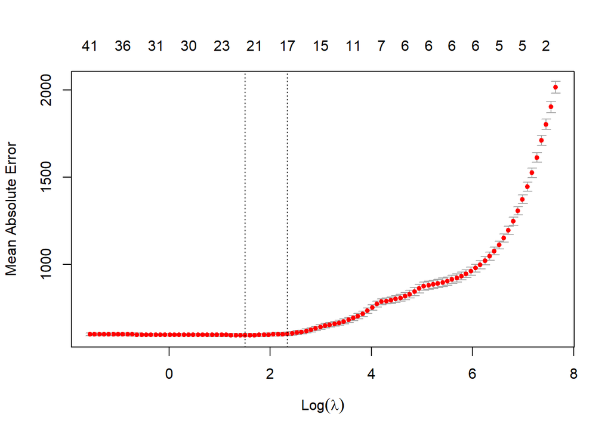

```r
plot(fit.list[[tmp.hour+1]])
```

lambda.min has 28 zero coefficients and 20 nonzero coefficients lambda.1se has 31 zero coefficients and 17 nonzero coefficients

For instance: [1] “MAPE with min lambda for Hour 5 is 1.38 %” (28 zero coefficients) [1] “MAPE with 1se lambda for Hour 5 is 1.44 %” (31 zero coefficients)

[1] “MAPE with min lambda for Hour 10 is 4.27 %” (26 zero coefficients) [1] “MAPE with 1se lambda for Hour 10 is 4.34 %” (27 zero coefficients)

[1] “MAPE with min lambda for Hour 15 is 3.77 %” (12 zero coefficients) [1] “MAPE with 1se lambda for Hour 15 is 3.99 %” (31 zero coefficients)

We could not detect any relationship between these hours.

As we can see we have a huge variable selection because our constraint space with respect to lasso is not smooth contrary to ridge regression case. In lasso regression, max likelihood calculation is not included because we do not set any distribution. We just try make an convex optimization in order to ensure the fitness of the model. So, it is not possible to examine the coefficients within some distribution.

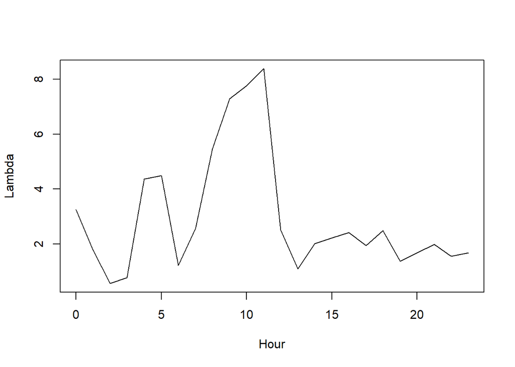

```r
#Here is the chosen lambdas:
plot(x=0:23,y=chosen.lambdas.min,type="l",xlab="Hour",ylab="Lambda")
```

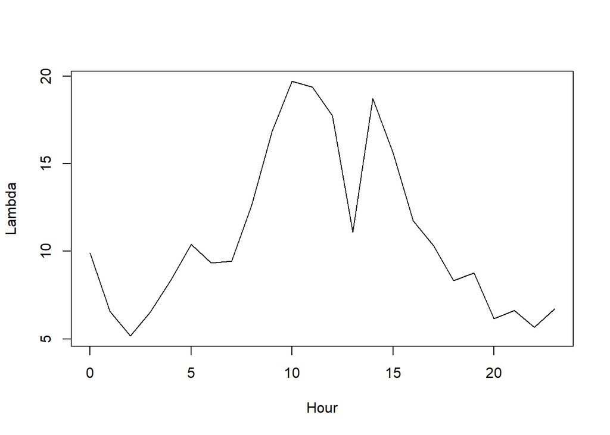

```r
plot(x=0:23,y=chosen.lambdas.1se,type="l",xlab="Hour",ylab="Lambda")
```

PART E

```r
# For part e we will use "penalized" package. In the introduction part of the vignette,
# it is said that lasso regression with fused penalties as Tibshirani explained can be used.
library(penalized,quietly = T)
```

```r
param.set<-expand.grid(Lambda1=c(100,20,5,2,0.5),
                       Lambda2=c(100,20,5,2,0.5))

full.test.dat<-c()
chosen.lambdas<-c()
fit.list<-list()
all.param.result<-c()
for(tmp.hour in 0:23){

  train.tmp<-train.data %>% filter(Hour==tmp.hour)
  test.tmp<-test.data %>% filter(Hour==tmp.hour)

  param.result<-c()
  for(param in 1:nrow(param.set)){
    lambda1.val<-param.set[param,1]
    lambda2.val<-param.set[param,2]

    set.seed(123)
    fold.list<-caret::createFolds(train.tmp$Consumption,k = 10)

    cl=makeCluster(8)
    registerDoSNOW(cl)
    progress <- function(n) cat(sprintf("task %d is complete\n", n))
    opts <- list(progress=progress)

    mape.res<-foreach(tmp.fold=fold.list,
                      .combine=c,
                      #.options.snow=opts,
                      .packages = c("penalized")) %dopar%{
                        train.tmp.fold<-train.tmp[-tmp.fold,]
                        test.tmp.fold<-train.tmp[tmp.fold,]

                        fit.tmp.fold<-penalized(response = train.tmp.fold$Consumption,
                                                penalized = train.tmp.fold[,4:ncol(train.tmp.fold)],
                                                lambda1 = lambda1.val,lambda2 = lambda2.val,
                                                maxiter=25,#default
                                                fusedl = TRUE)

                        predictions.fold<-predict(object = fit.tmp.fold,penalized = test.tmp.fold[,4:ncol(test.tmp.fold)])[,"mu"]
                        mape_fnc(actual = test.tmp.fold$Consumption,prediction = predictions.fold)
                      }
    stopCluster(cl)

    param.result<-bind_rows(param.result,tibble(hour=tmp.hour,lambda1=lambda1.val,lambda2=lambda2.val,fold_no=1:10,mape=mape.res))
    #print(paste0("paramset: ",param))
  }
  all.param.result<-bind_rows(all.param.result,param.result)
  param.final<-param.result %>% group_by(lambda1,lambda2) %>%
    summarise(avg_mape=mean(mape),.groups="keep") %>%
    ungroup()

  selected<-param.final %>%
    filter(avg_mape==min(avg_mape)) %>%
    select(lambda1,lambda2)
  chosen.lambdas<-bind_rows(chosen.lambdas,selected)

  fit.tmp<-penalized(response = train.tmp$Consumption,
                     penalized = train.tmp[,4:ncol(train.tmp)],
                     lambda1 = selected$lambda1,lambda2 = selected$lambda2,
                     maxiter=25,
                     fusedl = TRUE,trace = FALSE)
  fit.list[[tmp.hour+1]]<-fit.tmp
  predictions.tmp<-predict(object = fit.tmp,penalized = test.tmp[,4:ncol(test.tmp)])[,"mu"]
  test.tmp$Predictions<-predictions.tmp
  full.test.dat<-rbind(full.test.dat,test.tmp)

  mape_res<-mape_fnc(actual = test.tmp$Consumption,prediction = test.tmp$Predictions)
  print(paste0("MAPE for Hour ",tmp.hour," is ",round(mape_res,2)," %"))
}
```

```
## [1] "MAPE for Hour 0 is 2.11 %"
## [1] "MAPE for Hour 1 is 2.16 %"
## [1] "MAPE for Hour 2 is 2.45 %"
## [1] "MAPE for Hour 3 is 2.16 %"
## [1] "MAPE for Hour 4 is 2.31 %"
## [1] "MAPE for Hour 5 is 1.66 %"
## [1] "MAPE for Hour 6 is 2.44 %"
## [1] "MAPE for Hour 7 is 2.59 %"
## [1] "MAPE for Hour 8 is 3.83 %"
## [1] "MAPE for Hour 9 is 5.18 %"
## [1] "MAPE for Hour 10 is 5.12 %"
## [1] "MAPE for Hour 11 is 5.55 %"
## [1] "MAPE for Hour 12 is 5.13 %"
## [1] "MAPE for Hour 13 is 5.42 %"
## [1] "MAPE for Hour 14 is 5.24 %"
## [1] "MAPE for Hour 15 is 5.02 %"
## [1] "MAPE for Hour 16 is 4.37 %"
## [1] "MAPE for Hour 17 is 4.83 %"
## [1] "MAPE for Hour 18 is 1.65 %"
## [1] "MAPE for Hour 19 is 2.93 %"
## [1] "MAPE for Hour 20 is 1.74 %"
## [1] "MAPE for Hour 21 is 2.1 %"
## [1] "MAPE for Hour 22 is 1.76 %"
## [1] "MAPE for Hour 23 is 2.47 %"
```

```r
Predictions.all<-Predictions.all %>% left_join(full.test.dat %>%
                                                 select(Date,Hour,Predictions) %>%
                                                 rename(fusedlasso=Predictions),by=c("Date","Hour"))
mape_res<-mape_fnc(actual = full.test.dat$Consumption,prediction = full.test.dat$Predictions)
print(paste0("Total MAPE is ",round(mape_res,2)," %"))
```

```
## [1] "Total MAPE is 3.34 %"
```

```r
chosen.lambdas
```

```
## # A tibble: 24 x 2
##    lambda1 lambda2
##      <dbl>   <dbl>
##  1   100       0.5
##  2     0.5   100
##  3   100     100
##  4   100       0.5
##  5   100     100
##  6     0.5   100
##  7   100     100
##  8     0.5     0.5
##  9   100       0.5
## 10   100     100
## # ... with 14 more rows
```

```r
# Looks like same for all hours
unique(param.final$avg_mape)
```

```
##  [1] 3.361997 3.361997 3.361997 3.361996 3.361993 3.361994 3.361994 3.361994
##  [9] 3.361994 3.361990 3.361990 3.361989 3.361989 3.361989 3.361986 3.361966
## [17] 3.361966 3.361965 3.361965 3.361962 3.361849 3.361849 3.361849 3.361849
## [25] 3.361846
```

```r
# Different lambda values do not lead to different mape value.
# The reason for this may be overfit or underfit because of maxiter number.
# Increasing this number leads to increase running time so much.
# That's why we couldn't make too many experiment.
```

```r
# Fit example for 5th Hour
tmp.hour<-5
coefficients(fit.list[[tmp.hour+1]],"all")
```

```
##      (Intercept)  Lag_day2_hour_0  Lag_day2_hour_1  Lag_day2_hour_2
##     1.330779e+03    -1.620233e-03    -1.620233e-03    -1.620233e-03
##  Lag_day2_hour_3  Lag_day2_hour_4  Lag_day2_hour_5  Lag_day2_hour_6
##    -1.620233e-03     1.727741e-02     1.727741e-02     1.727741e-02
##  Lag_day2_hour_7  Lag_day2_hour_8  Lag_day2_hour_9 Lag_day2_hour_10
##    -1.732482e-02    -7.090037e-02    -7.090037e-02    -7.090037e-02
## Lag_day2_hour_11 Lag_day2_hour_12 Lag_day2_hour_13 Lag_day2_hour_14
##    -7.090037e-02    -3.795318e-02     1.173509e-02     1.173509e-02
## Lag_day2_hour_15 Lag_day2_hour_16 Lag_day2_hour_17 Lag_day2_hour_18
##     1.173509e-02     3.203373e-02     3.203373e-02     1.087584e-01
## Lag_day2_hour_19 Lag_day2_hour_20 Lag_day2_hour_21 Lag_day2_hour_22
##     1.087584e-01     1.376889e-01     1.376889e-01     1.376889e-01
## Lag_day2_hour_23  Lag_day7_hour_0  Lag_day7_hour_1  Lag_day7_hour_2
##     1.376889e-01     8.938667e-03     8.938667e-03     8.938667e-03
##  Lag_day7_hour_3  Lag_day7_hour_4  Lag_day7_hour_5  Lag_day7_hour_6
##     8.938667e-03     8.938667e-03     5.323263e-02     7.382654e-02
##  Lag_day7_hour_7  Lag_day7_hour_8  Lag_day7_hour_9 Lag_day7_hour_10
##     7.382654e-02     7.155962e-02     7.155962e-02     2.157090e-02
## Lag_day7_hour_11 Lag_day7_hour_12 Lag_day7_hour_13 Lag_day7_hour_14
##     2.157090e-02    -9.711380e-03    -9.711380e-03    -9.711380e-03
## Lag_day7_hour_15 Lag_day7_hour_16 Lag_day7_hour_17 Lag_day7_hour_18
##    -1.082303e-02    -1.082303e-02    -1.232401e-02    -2.218119e-02
## Lag_day7_hour_19 Lag_day7_hour_20 Lag_day7_hour_21 Lag_day7_hour_22
##    -2.218119e-02    -2.187219e-02    -2.187219e-02    -2.969698e-02
## Lag_day7_hour_23
##    -2.969698e-02
```

PART F

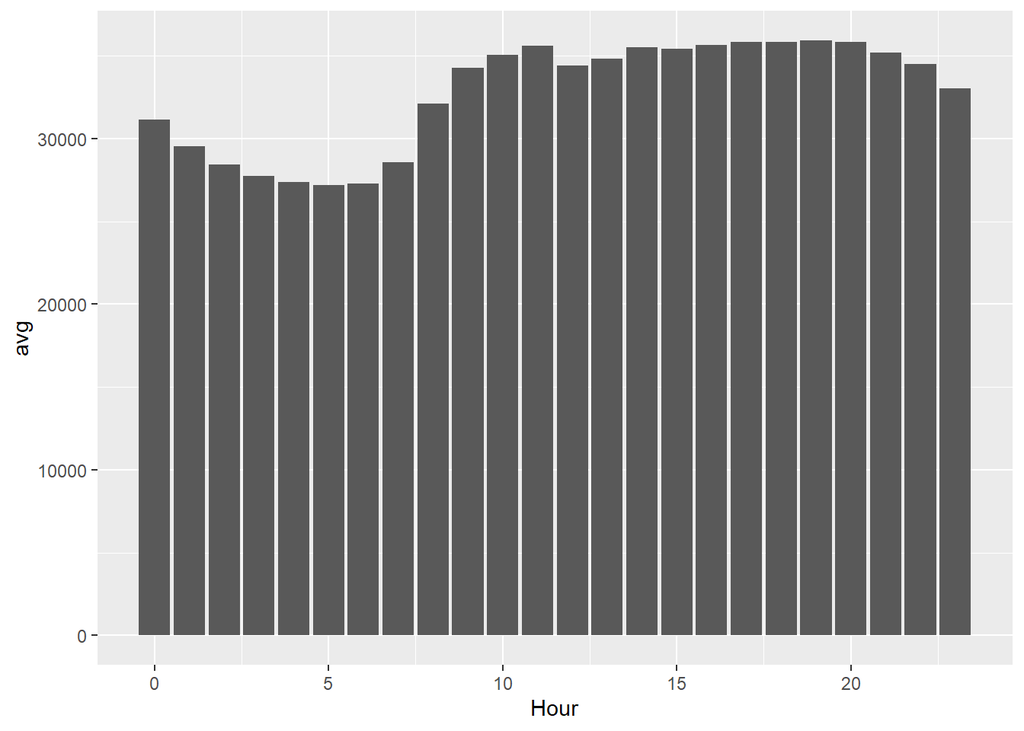

```r
# The reason why daytime our models have higher MAPE is because
# variance and mean of electricity consumption is higher in those time of day.
# Therefore it is hard to make good prediction for those hours.

rawdat %>% group_by(Hour) %>% summarise(avg=mean(Consumption),.groups="keep") %>%
  ggplot(aes(Hour,avg))+
  geom_bar(stat = "identity")
```

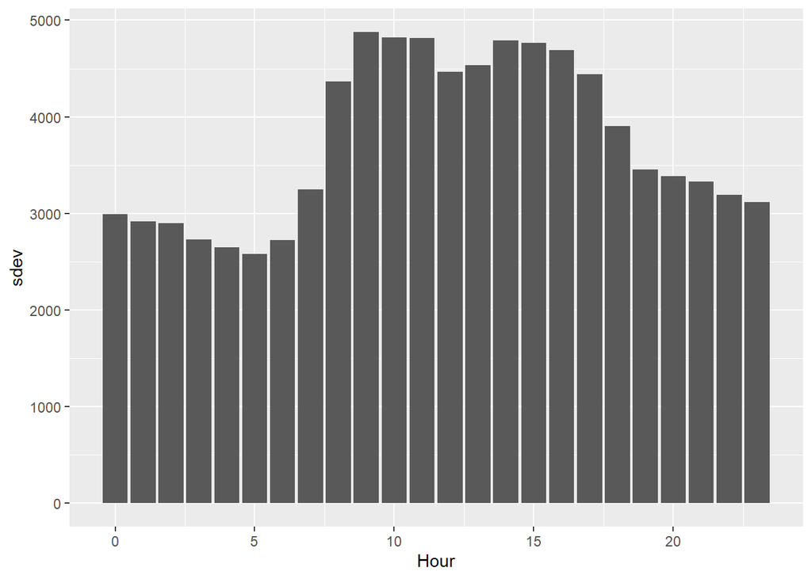

```r
rawdat %>% group_by(Hour) %>% summarise(sdev=sd(Consumption),.groups="keep") %>%
  ggplot(aes(Hour,sdev))+
  geom_bar(stat = "identity")
```

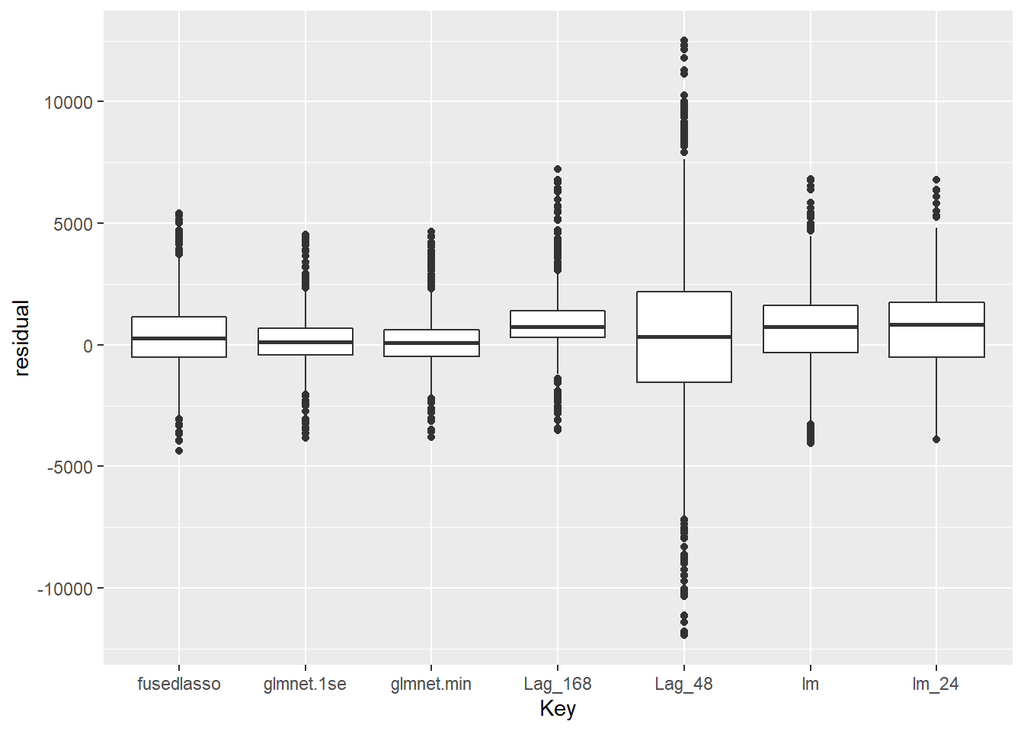

```r
perf_data<-Predictions.all
perf_data<-perf_data %>%
   pivot_longer(!c(Date,Hour,Consumption),names_to="Key",values_to="Prediction") %>%
   mutate(residual=Consumption-Prediction)

perf_data %>%
  ggplot(aes(x=Key,y=residual))+
  geom_boxplot()
```

```r
perf_data %>% group_by(Key) %>%
  summarise(mse=mean(residual^2),bias=mean(residual),mape=mean(abs(residual/Consumption)),.groups="keep")
```

```
## # A tibble: 7 x 4
## # Groups:   Key [7]
##   Key              mse  bias   mape
##   <chr>          <dbl> <dbl>  <dbl>
## 1 fusedlasso  2484334.  425. 0.0334
## 2 glmnet.1se  1496032.  202. 0.0249
## 3 glmnet.min  1468345.  154. 0.0245
## 4 Lag_168     2820139.  967. 0.0345
## 5 Lag_48     14664149.  336. 0.0806
## 6 lm          3656455.  784. 0.0423
## 7 lm_24       3495454.  771. 0.0436
```

fusedlasso is from part e. glmnet.1se and glmnet.min are from part d. lag_148 and lag_48 are from part a. lm is from part b and lm_24 is from part c.

Lasso regression has minimum performance metrics. And the second best is the fused lasso regression. Our naive forecast beats linear regression models. Even though Lag_48’s median residuals are close to zero, it has the worst performance because of high variance.

glmnet models have similar properties with respect to the similar median and interquartile range. Also, lm and lm_24 models have similar properties with respect to median and interquartile range. We already find from previous tasks that mape values in linear regression higher than lasso regression. And boxplot shows this situation again due to wider interquartile range.

In addition, our primary predictions from part a has much more difference than others. Also, they pose difference in each other due to wider interquartile range and not equal median.